# Clase 5 - Trabajo con Fechas - Diplomatura UNSAM

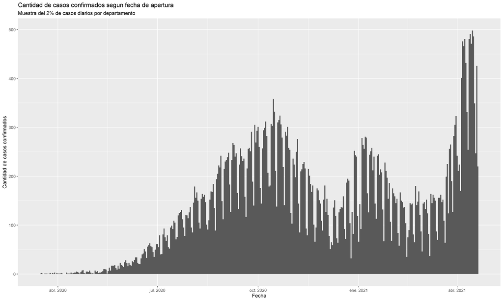

## Cargamos librerias

```r
library(tidyverse)
library(lubridate)
```

## Cargamos las bases

En esta clase trabajaremos en paralelo con dos bases de datos. Una muestra de la base argentina de casos de Covid19 y una base con tweets que mencionan la palabra “vacuna”. Ambas bases cuentan con variables de tipo fecha. Aun cuando ambas permitan tratamientos similares, veremos que la clase de variable en cuestión no es idéntica en una y otra base [^1].

- En la `base.covid`, trabajaremos con la variable **fecha_apertura**, la cual nos indica la fecha en la cual fue “abierto” el caso. Es decir, el momento a partir del cual se empieza a tomar registro de una persona que fue analizada por ser posible caso positivo de COVID.
- En la base `vacuna.tweets`, trabajaremos con la variable **created_at** que nos indica cuando fue envíado cada uno de los tweets que constituyen los registros de la base

```r
base.covid <- readRDS("../Fuentes/base_covid_sample.RDS")
vacuna.tweets <- readRDS("../Fuentes/Bases adicionales/vacuna.tweets.RDS")
```

Veamos que rango de tiempo abarcan nuestros registros en la base de datos del covid

```r
range(base.covid$fecha_apertura)
```

```
[1] "2020-03-12" "2021-04-20"
```

¿Qué tipo de variable es **fecha_apertura** en la `base.covid`??

```r
class(base.covid$fecha_apertura)
```

```
[1] "Date"
```

Es un tipo de variable de tiempo. Tenemos tres tipos de variables de tiempo principales en R:

- Date: (Sólo Año, Mes y Día).
- Time: (Un horario, sin especificar de que día es)
- Date-time: (Año, Mes, Día y horario)

Pasemos a la base `vacuna.tweets`. ¿Qué rango de tiempo tenemos acá?

```r
range(vacuna.tweets$created_at)
```

```
[1] "2021-03-19 09:14:45 UTC" "2021-03-19 15:11:25 UTC"
```

¿Qué tipo de variable es **created_at** en la base `vacuna.tweets`?

```r
class(vacuna.tweets$created_at)
```

```
[1] "POSIXct" "POSIXt"
```

Es un tipo de variable de tiempo completa (del estilo Date-Time) que está expresada en la zona horaria UTC).

> ¿Cual creen que es la principal ventaja de contar con una fecha expresada de esta forma?

## Lubridate

El paquete `lubridate` es hoy en día uno de los más utilizados para trabajar con fechas en R. Tiene un conjunto de funciones con nombres intuitivos que permiten entre otras cosas:

- Construir variables de tipo fecha a partir de números o caracteres
- Extraer información de variables ya constituídas como fechas
- Realizar operatorias con fechas (ej: calculo de distancias temporales entre dos registros)

### ¿Y ahora?

¿En qué momento del tiempo estoy parado según R? (En este caso es el momento en que retoqué por última vez este material)

```r
today()
```

```
[1] "2021-04-28"
```

```r
now()
```

```
[1] "2021-04-28 19:05:42 -03"
```

¿Cuántos días me quedan hasta el comienzo de la diplomatura?

```r
comienzo_diplo <- "2021-05-04"

comienzo_diplo - today()
```

```
Error in `-.Date`(comienzo_diplo, today()) :
  can only subtract from "Date" objects
```

Aunque R nos muestre como resultado de la función `today()` algo similar a un objeto de tipo character, no podemos simplemente a través de un character hacerle entender a R que estamos refiriendo a una fecha.  
Necesitamos explicitamente crear objetos de clase fecha!

### Crear Fechas

Hay un set de funciones del paquete *lubridate* que siguen la siguiente lógica:  
Mediante la combinacion de los caracteres **dmy_hms** que representan a día(d), mes(m), año(y), hora(h), minuto(m) y segundo(s) podemos convertir un número (o un string) hacia una fecha.

Por ejemplo, la función `ymd()` me permite pasar un numero que contenga año, mes y dia y transformarlo en formato fecha.

```r
#Distintas variantes que admite la función
ymd(20210504)
```

```
[1] "2021-05-04"
```

```r
ymd("20210504")
```

```
[1] "2021-05-04"
```

```r
ymd("2021/05/04")
```

```
[1] "2021-05-04"
```

¿Cuántos días me quedan hasta el comienzo de la diplomatura?

```r
ymd(20210504) - today()
```

```
Time difference of 6 days
```

Veamos algún otro ejemplo de creación de fechas con un ordenamiento distinto de día mes y año; y con el agregado de horas, segundos y minutos.

```r
ejemplo2 <- "20/05/2020 18:20:40"
class(ejemplo2)
```

```
[1] "character"
```

```r
ejemplo2_ok<- dmy_hms(ejemplo2)
ejemplo2_ok
```

```
[1] "2020-05-20 18:20:40 UTC"
```

```r
class(ejemplo2_ok)
```

```
[1] "POSIXct" "POSIXt"
```

Para formatos un poco menos estandarizados, la función `parse_date_time()` nos puede ser útil para transformar una variable character hacia una variable fecha.

```r
vector_fechas_importado <- c("Apr-20","May-20","Jun-20")

parse_date_time(vector_fechas_importado, orders = 'my')
```

```
[1] "2020-04-01 UTC" "2020-05-01 UTC" "2020-06-01 UTC"
```

> Practica: Copiar los siguientes vectores en un script y transformarlos correctamente a vectores de tipo fecha.

```r
fechas_1<- c("05-04-2021","01-01-1959","08-03-1917","09-14-1867")
fechas_2<- c("22-06-1986 19:06:00","22-06-1986 19:10:15",
                "09-12-2018 22:02:10")
fechas_3 <- c("2020-April-10","2020/May/11","2020-June 12")
```

### Extraccion de informacion de la fecha

Otra aplicación útil de *lubridate* es que nos permite extraer muy intuitivamente información cuando contamos con una variable construida como fecha.

```r
base.covid.fechas<- base.covid %>%
  mutate(anio = year(fecha_apertura),
         semestre  = semester(fecha_apertura),
         trimestre = quarter(fecha_apertura),
         mes       = month(fecha_apertura),
         mes.nombre = month(fecha_apertura,label = TRUE),
         dia.del.mes       = mday(fecha_apertura),
         dia.del.anio      = yday(fecha_apertura),
         semana       = week(fecha_apertura),
         dia.numero= wday(fecha_apertura),
         dia.nombre= wday(fecha_apertura, label = TRUE),
         hora = hour(fecha_apertura),
         minutos = minute(fecha_apertura))
```

Veamos como quedan algunas de estas nuevas columnas.

```r
base.covid.fechas %>%
  select(fecha_apertura,anio,mes,dia.del.mes,dia.del.anio,dia.nombre,hora)
```

| fecha_apertura | anio | mes | dia.del.mes | dia.del.anio | dia.nombre | hora |
| --- | --- | --- | --- | --- | --- | --- |
| 2020-03-12 | 2020 | 3 | 12 | 72 | jue\\. | 0 |
| 2020-03-13 | 2020 | 3 | 13 | 73 | vie\\. | 0 |
| 2020-03-16 | 2020 | 3 | 16 | 76 | lun\\. | 0 |
| 2020-03-17 | 2020 | 3 | 17 | 77 | mar\\. | 0 |
| 2020-03-18 | 2020 | 3 | 18 | 78 | mié\\. | 0 |
| 2020-03-19 | 2020 | 3 | 19 | 79 | jue\\. | 0 |
| 2020-03-20 | 2020 | 3 | 20 | 80 | vie\\. | 0 |
| 2020-03-21 | 2020 | 3 | 21 | 81 | sáb\\. | 0 |
| 2020-03-22 | 2020 | 3 | 22 | 82 | dom\\. | 0 |
| 2020-03-23 | 2020 | 3 | 23 | 83 | lun\\. | 0 |

[output cut: 990 more lines]

> Practica: Creen un dataframe a partir del primer vector del ejercicio de practica anterior. Luego generen 3 nuevas columnas que detallen para cada fecha en cuestión: el numero de semana del año, el numero de dia del año, y el nombre del día

### Operaciones con fechas

```r
fecha <- base.covid$fecha_apertura[3]
fecha
```

```
[1] "2020-03-16"
```

Probemos algunas operaciones sencillas…

```r
fecha+ days(2) # Le sumo dos días a la fecha
```

```
[1] "2020-03-18"
```

```r
fecha+ months(1) + days(7)  # Le sumo un mes y una semana a la fecha
```

```
[1] "2020-04-23"
```

Importante tener en cuenta que tipo de resultado buscamos. **No todos los meses tienen la misma cantidad de días**. ¿Queremos construir el mismo día del mes siguiente, o queremos ver por ejemplo la evolución de un dato 30 días después?

```r
fecha+ months(1)
```

```
[1] "2020-04-16"
```

```r
fecha+ days(30)
```

```
[1] "2020-04-15"
```

Importante notar que:

- Los nombres de funciones para **extraer** informacion de las fechas llevan el **singular** (ej: day,month,hour)
- Las nombres de funciones para **transformar** las fechas llevan el **plural** (ej: days, months,hours).

> Practica: Filtrar un conjunto de 5 semanas consecutivas en la base de datos covid. ¿Qué dia de la semana se abren menos casos?

```r
base.covid.fechas <-  base.covid.fechas %>%
mutate(tiempo.diagnostico = fecha_diagnostico - fecha_inicio_sintomas)

class(base.covid.fechas$tiempo.diagnostico)
```

```
[1] "difftime"
```

Una resta de fechas provoca en este caso un objeto “difftime”. Podemos ver ahora por ejemplo cuánto es el promedio de tiempo por provincia

```r
base.covid.fechas %>%
  group_by(residencia_provincia_nombre) %>%
  summarise(tiempo.promedio = mean(tiempo.diagnostico,na.rm = T)) %>%
  arrange(tiempo.promedio)
```

| residencia_provincia_nombre | tiempo.promedio |
| --- | --- |
| Jujuy | 1.075472 days |
| Santa Cruz | 3.071228 days |
| La Pampa | 3.555818 days |
| Santiago del Estero | 3.582482 days |
| San Juan | 3.946333 days |
| Chaco | 4.037849 days |
| Córdoba | 4.051207 days |
| Río Negro | 4.307988 days |
| CABA | 4.448054 days |
| Catamarca | 4.472527 days |

[output cut: 15 more lines]

> Practica: ¿Cuanto fue el máximo tiempo registrado en toda la base de datos entre una fecha de inicio de sintomas y el diagnóstico del caso? ¿En qué departamento y provincia ocurrió? Detallar año y mes del caso en cuestión
[^1]: Esta clase está inspirada en el capítulo 16 del libro [R for Data Science](https://es.r4ds.hadley.nz/fechas-y-horas.html). Allí pueden profundizar algunos aspectos que exceden los alcances de la misma